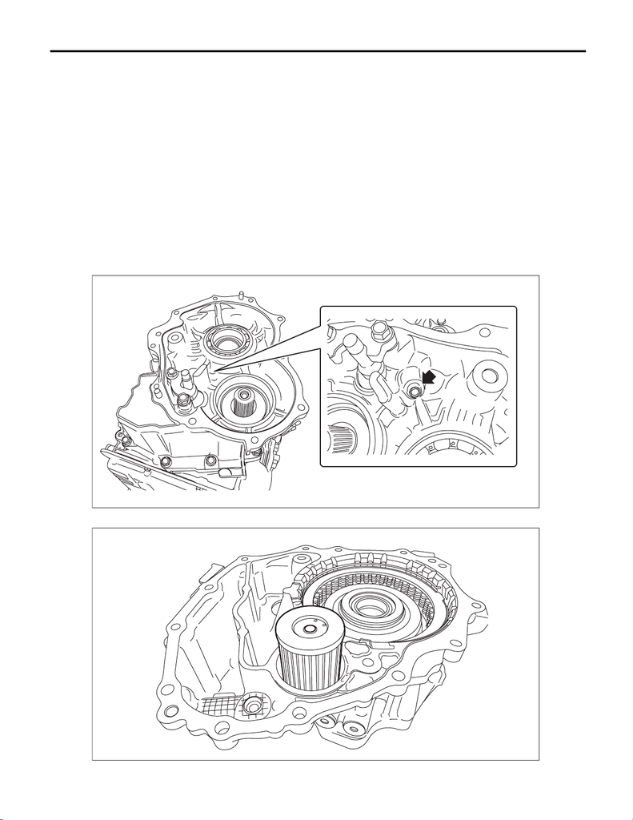

CVT(TR690)-165

Intermediate Case

CONTINUOUSLY VARIABLE TRANSMISSION

34.Intermediate Case

A: REMOVAL

1) Remove the transmission assembly from vehicle body. <Ref. to CVT(TR690)-56, REMOVAL, Automatic

Transmission Assembly.>

2) Remove the extension case. <Ref. to CVT(TR690)-142, REMOVAL, Extension Case.>

3) Remove the parking pawl. <Ref. to CVT(TR690)-163, REMOVAL, Parking Pawl.>

4) Remove the rear drive shaft. <Ref. to CVT(TR690)-146, REMOVAL, Rear Drive Shaft.>

5) Remove the transfer clutch assembly. <Ref. to CVT(TR690)-151, REMOVAL, Transfer Clutch.>

6) Remove the center differential carrier. <Ref. to CVT(TR690)-154, REMOVAL, Center Differential Carrier.>

7) Remove the transfer reduction driven gear assembly. <Ref. to CVT(TR690)-158, REMOVAL, Transfer Re-

duction Driven Gear.>

8) Remove the intermediate case.

NOTE:

• The total number of intermediate case mounting bolts is 14.

• Inside the transmission is a single bolt (arrowed).

9) Remove the CVTF filter.

AT-07366

AT-07367

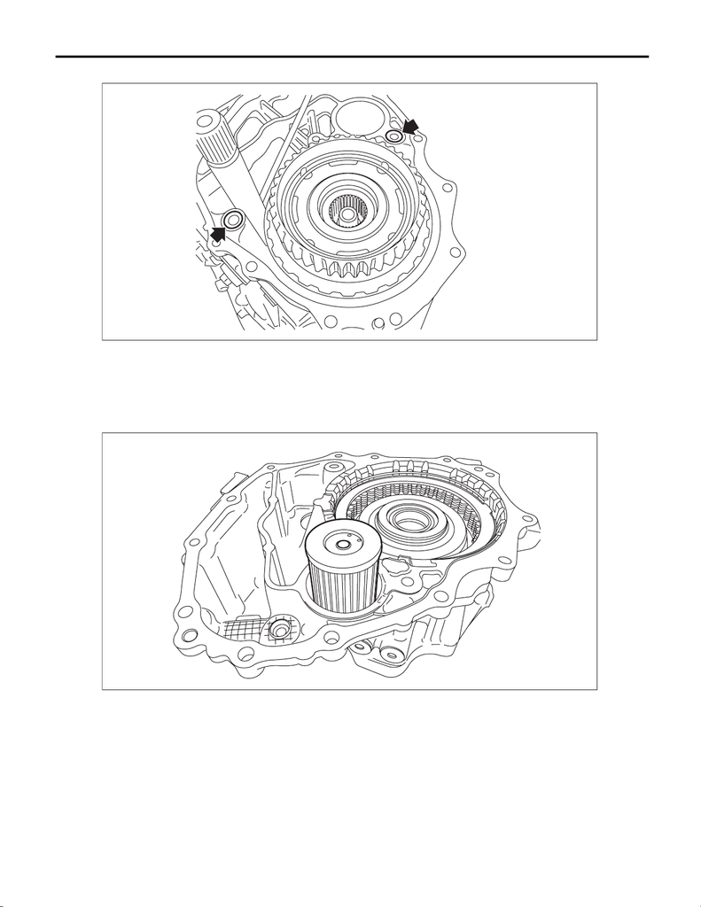

CVT(TR690)-166

Intermediate Case

CONTINUOUSLY VARIABLE TRANSMISSION

10) Remove the O-ring from the transmission case.

B: INSTALLATION

1) Clean the mating surface of intermediate case and transmission case.

2) Face the O-ring side of the CVTF filter to the intermediate case side, and install the CVTF filter.

NOTE:

Apply CVTF to the O-rings.

AT-05295

AT-07367

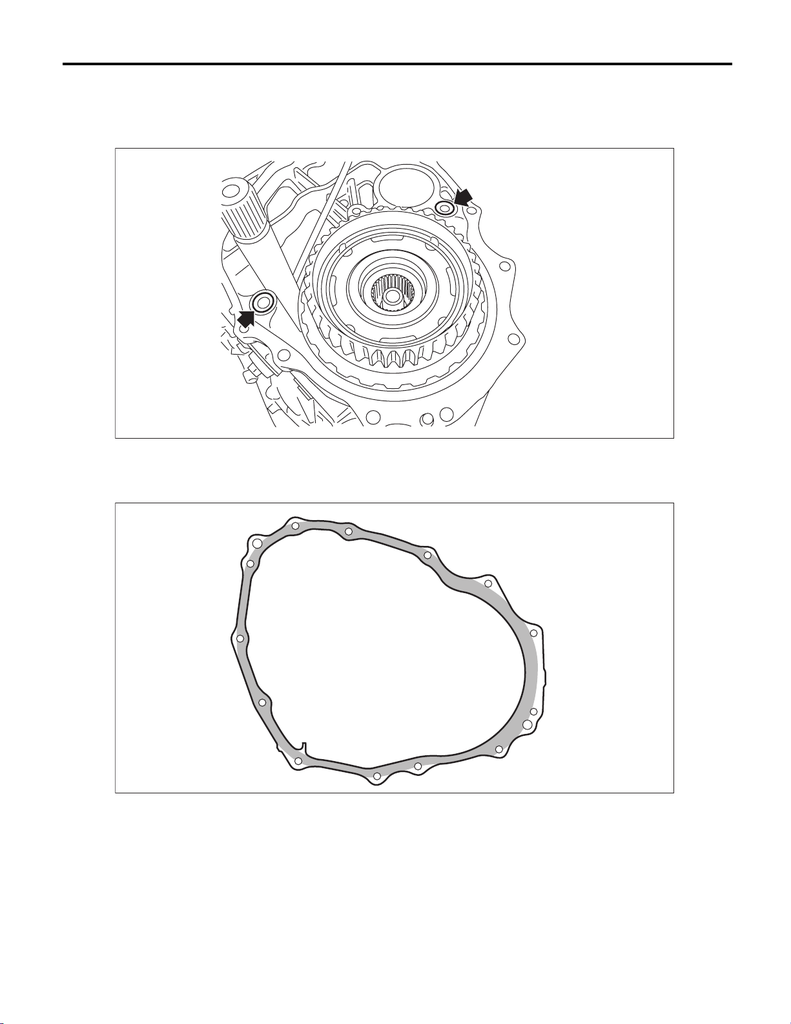

CVT(TR690)-167

Intermediate Case

CONTINUOUSLY VARIABLE TRANSMISSION

3) Install the O-ring to the transmission case.

NOTE:

• Use new O-rings.

• Apply CVTF to the O-rings.

4) Apply liquid gasket to intermediate case seamlessly.

Liquid gasket:

THREE BOND 1215B or equivalent

AT-05295

AT-05223

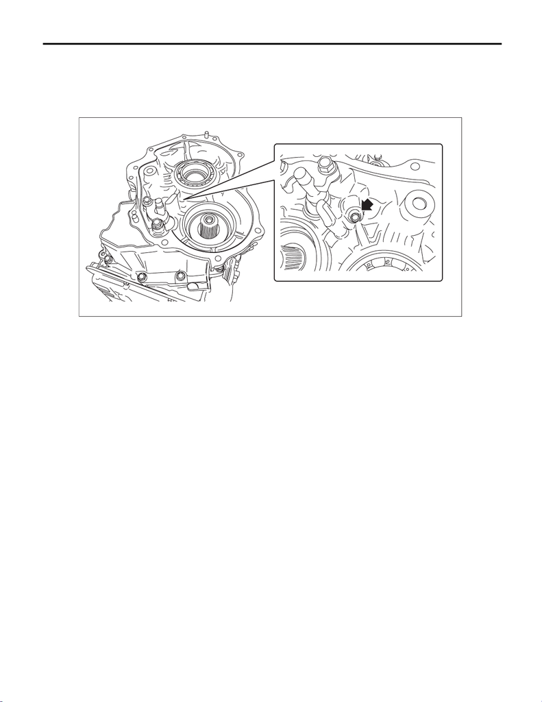

CVT(TR690)-168

Intermediate Case

CONTINUOUSLY VARIABLE TRANSMISSION

5) Install the intermediate case and the transmission hanger to the transmission case.

NOTE:

Make sure to install the arrowed bolt.

Tightening torque:

25 N·m (2.5 kgf-m, 18.4 ft-lb)

6) Install the transfer reduction driven gear assembly. <Ref. to CVT(TR690)-158, INSTALLATION, Transfer

Reduction Driven Gear.>

7) Install the center differential carrier. <Ref. to CVT(TR690)-155, INSTALLATION, Center Differential Car-

rier.>

8) Install the transfer clutch assembly. <Ref. to CVT(TR690)-151, INSTALLATION, Transfer Clutch.>

9) Install the rear drive shaft. <Ref. to CVT(TR690)-146, INSTALLATION, Rear Drive Shaft.>

10) Install the parking pawl. <Ref. to CVT(TR690)-164, INSTALLATION, Parking Pawl.>

11) Install the extension case. <Ref. to CVT(TR690)-143, INSTALLATION, Extension Case.>

12) Install the transmission to vehicle. <Ref. to CVT(TR690)-69, INSTALLATION, Automatic Transmission

Assembly.>

AT-07366

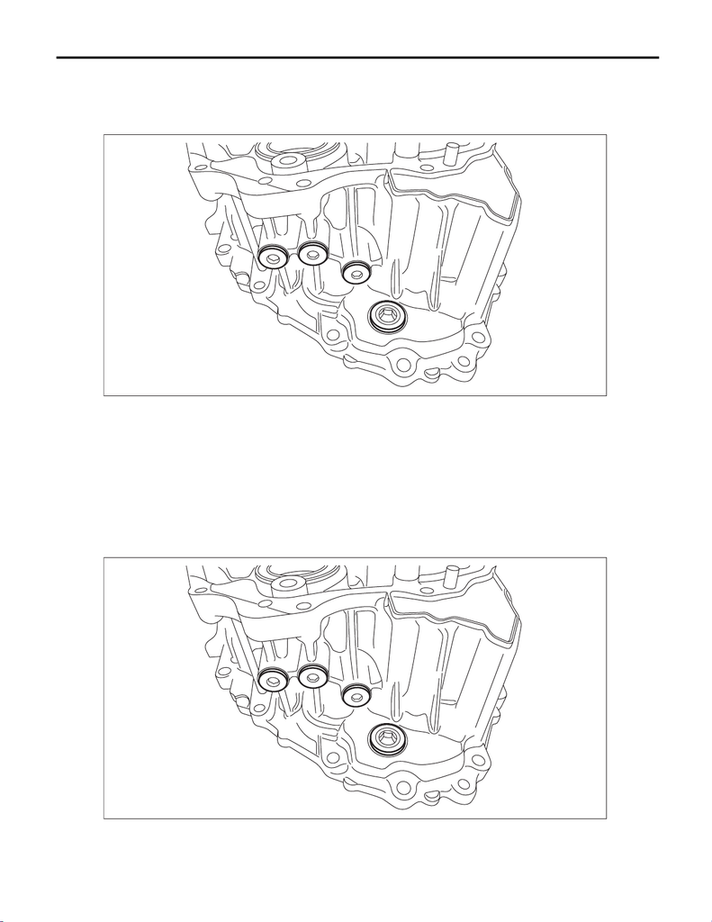

CVT(TR690)-169

Intermediate Case

CONTINUOUSLY VARIABLE TRANSMISSION

C: DISASSEMBLY

1) Remove the parking support.

2) Remove the CVTF filler plug.

3) Remove all plugs from intermediate case.

4) Remove the reverse brake assembly. <Ref. to CVT(TR690)-172, DISASSEMBLY, Reverse Brake Assem-

bly.>

D: ASSEMBLY

1) Install the reverse brake. <Ref. to CVT(TR690)-175, ASSEMBLY, Reverse Brake Assembly.>

2) Install all plugs to intermediate case.

Tightening torque:

25 N·m (2.5 kgf-m, 18.4 ft-lb)

NOTE:

Use new O-rings.

AT-07401

AT-07401

[figure not shown]

CVT(TR690)-170

Intermediate Case

CONTINUOUSLY VARIABLE TRANSMISSION

3) Install the parking support.

Tightening torque:

25 N·m (2.5 kgf-m, 18.4 ft-lb)

4) Install the CVTF filler plug.

NOTE:

Replace the gasket of CVTF filler plug with a new part after installing the transmission assembly to vehicle

and adjusting CVTF fluid.

E: INSPECTION

• Check the intermediate case for fissures, cracks or damage.

• Check for leakage of CVTF from the connections between intermediate case and transmission case, and

between intermediate case and extension case.